None

# JWST Pipeline Validation Testing Notebook: Point Source Flux Conservation Modeshep

**Instruments Affected**: MIRI

Tested on MIRI Simulated data

Introduction  
Imports  
Run JWST Pipeline  
Examine Input and Output Data  
About This Notebook

## Author: Isha Nayak

## Last Modified: September 15

## The purpose of this notebook is to check if you input either a flat point source or flat extended source, then the output is also flat. We check the flatness of a source by inputting a known flat source, then checking the output three different ways: (1) our own code which sums up the total flux, (2) the cube build algorithm, and (3) extract 1D algorithm. We want to make sure nothing strange is happening during the cube build and extract 1D steps.

```python
# Create a temporary directory to hold notebook output, and change the working directory to that directory.
from tempfile import TemporaryDirectory
import os
data_dir = TemporaryDirectory()
os.chdir(data_dir.name)
print(data_dir)
```

```
<TemporaryDirectory '/internal/data1/jenkins/workspace/Notebooks/jwst_validation_notebooks_spacetelescope/tmp/tmp88xsx987'>
```

```python
import os
if 'CRDS_CACHE_TYPE' in os.environ:
    if os.environ['CRDS_CACHE_TYPE'] == 'local':
        os.environ['CRDS_PATH'] = os.path.join(os.environ['HOME'], 'crds', 'cache')
    elif os.path.isdir(os.environ['CRDS_CACHE_TYPE']):
        os.environ['CRDS_PATH'] = os.environ['CRDS_CACHE_TYPE']
print('CRDS cache location: {}'.format(os.environ['CRDS_PATH']))
```

```
CRDS cache location: /grp/crds/cache
```

```python
# Check jwst pipeline version
import jwst
jwst.__version__
```

```
'1.8.2'
```

```python
#Import inject psf
import miri3d.tools.inject_psf as ip

#Import assign wcs
from jwst.assign_wcs import AssignWcsStep

#Import modshep
import miri3d.modshep.modshep as modshep

#Import plotting things
import matplotlib.pyplot as plt

#Import fits file things
from astropy.io import fits

#Import cube build
from jwst.cube_build import CubeBuildStep

#Import extract1D
from jwst.extract_1d import Extract1dStep

#Import table
from astropy.table import Table

import sys
from ci_watson.artifactory_helpers import get_bigdata
```

#### The output should be two scene files, two mock files, and two mockarea files.

```python
# Read association file in from artifactory

asnfile = get_bigdata('jwst_validation_notebooks',
                      'validation_data',
                      'cube_build',
                      'cube_build_miri_test',
                      'cube_testing.json')
```

```python
#Define band and channels
band_chan=['12A','34A','12B','34B','12C','34C']

#Define Channels 1 and 3
indiv1=['1A','3A','1B','3B','1C','3C']

#Define Channels 2 and 4
indiv2=['2A','4A','2B','4B','2C','4C']

#Define plot colors for each band
plot_color=['black','black','blue','blue','red','red']
```

#### Using D. Law's injest_psf code to first define a flat point source or flat extended source in a particular band/channel which does not depend on JWST pipeline for distortion transforms. Then this uses D. Law's modshep code as a standalone implementation of modified Sheperd's cube building algorithm. We need to correct units and plot the output from the modshep algorithm.

```
Setting up the dithers
Ndither =  2
Working on left half of detector
Setting up the coordinates
Setting up the scene
Projecting scene
Working on exposure 0
Doing coordinate projection
Projecting slices
Doing pixel value computation
Working on exposure 1
Doing coordinate projection
Projecting slices
Doing pixel value computation
Working on right half of detector
Setting up the coordinates
Setting up the scene
Projecting scene
Working on exposure 0
Doing coordinate projection
Projecting slices
Doing pixel value computation
Working on exposure 1
Doing coordinate projection
Projecting slices
Doing pixel value computation
Writing files
Done!
```

[output not shown]

```
Defining base reference coordinates
Reading 2 inputs
Wavelength limits: 4.89 - 5.74 micron
RA limits: 44.9992 - 45.0008 deg
DEC limits: -0.0006 - 0.0006 deg
XI limits: -2.925 - 2.925 deg
ETA limits: -2.405 - 2.405 deg
Cube X-Y-Z dimensions: [44, 36, 851] spaxels
Radius of influence in X-Y-Z direction: [3.076923076923077, 3.076923076923077, 2.5] pixels
Exponential weighting sigma: 0.7692307692307693 pixels
Using exponential weighting
Constructing cube:  0 % complete
Constructing cube:  5 % complete
Constructing cube:  10 % complete
Constructing cube:  15 % complete
Constructing cube:  20 % complete
Constructing cube:  25 % complete
Constructing cube:  30 % complete
Constructing cube:  35 % complete
Constructing cube:  40 % complete
Constructing cube:  45 % complete
Constructing cube:  50 % complete
Constructing cube:  55 % complete
Constructing cube:  60 % complete
Constructing cube:  65 % complete
Constructing cube:  70 % complete
Constructing cube:  75 % complete
Constructing cube:  80 % complete
Constructing cube:  85 % complete
Constructing cube:  90 % complete
Constructing cube:  96 % complete
Defining base reference coordinates
Reading 2 inputs
Wavelength limits: 7.49 - 8.75 micron
RA limits: 44.9992 - 45.0009 deg
DEC limits: -0.0008 - 0.0007 deg
XI limits: -3.315 - 3.315 deg
ETA limits: -2.975 - 2.975 deg
Cube X-Y-Z dimensions: [38, 34, 630] spaxels
Radius of influence in X-Y-Z direction: [3.529411764705882, 3.529411764705882, 2.5] pixels
```

[output cut: 35 more lines]

```
Doing pixel value computation
Working on right half of detector
Setting up the coordinates
Setting up the scene
Projecting scene
Working on exposure 0
Doing coordinate projection
Projecting slices
Doing pixel value computation
Working on exposure 1
Doing coordinate projection
Projecting slices
Doing pixel value computation
Writing files
Done!
```

[output not shown]

```
Defining base reference coordinates
Reading 2 inputs
Wavelength limits: 11.53 - 13.48 micron
RA limits: 44.9987 - 45.001 deg
DEC limits: -0.001 - 0.0009 deg
XI limits: -4.5 - 4.5 deg
ETA limits: -3.7 - 3.7 deg
Cube X-Y-Z dimensions: [44, 36, 651] spaxels
Radius of influence in X-Y-Z direction: [4.5, 4.5, 2.3333333333333335] pixels
Exponential weighting sigma: 1.0 pixels
Using exponential weighting
Constructing cube:  0 % complete
Constructing cube:  5 % complete
Constructing cube:  10 % complete
Constructing cube:  15 % complete
Constructing cube:  20 % complete
Constructing cube:  25 % complete
Constructing cube:  30 % complete
Constructing cube:  35 % complete
Constructing cube:  40 % complete
Constructing cube:  45 % complete
Constructing cube:  50 % complete
Constructing cube:  55 % complete
Constructing cube:  60 % complete
Constructing cube:  65 % complete
Constructing cube:  70 % complete
Constructing cube:  76 % complete
Constructing cube:  81 % complete
Constructing cube:  86 % complete
Constructing cube:  91 % complete
Constructing cube:  96 % complete
Defining base reference coordinates
Reading 2 inputs
Wavelength limits: 17.66 - 20.93 micron
RA limits: 44.9987 - 45.0015 deg
DEC limits: -0.0013 - 0.001 deg
XI limits: -5.425 - 5.425 deg
ETA limits: -4.375 - 4.375 deg
Cube X-Y-Z dimensions: [30, 24, 545] spaxels
Radius of influence in X-Y-Z direction: [5.142857142857143, 5.142857142857143, 2.0] pixels
```

[output cut: 36 more lines]

```
Doing pixel value computation
Working on right half of detector
Setting up the coordinates
Setting up the scene
Projecting scene
Working on exposure 0
Doing coordinate projection
Projecting slices
Doing pixel value computation
Working on exposure 1
Doing coordinate projection
Projecting slices
Doing pixel value computation
Writing files
Done!
```

[output not shown]

```
Defining base reference coordinates
Reading 2 inputs
Wavelength limits: 5.64 - 6.62 micron
RA limits: 44.9993 - 45.0008 deg
DEC limits: -0.0007 - 0.0006 deg
XI limits: -2.925 - 2.925 deg
ETA limits: -2.405 - 2.405 deg
Cube X-Y-Z dimensions: [44, 36, 981] spaxels
Radius of influence in X-Y-Z direction: [1.5384615384615385, 1.5384615384615385, 2.5] pixels
Exponential weighting sigma: 0.7692307692307693 pixels
Using exponential weighting
Constructing cube:  0 % complete
Constructing cube:  4 % complete
Constructing cube:  9 % complete
Constructing cube:  14 % complete
Constructing cube:  19 % complete
Constructing cube:  24 % complete
Constructing cube:  29 % complete
Constructing cube:  34 % complete
Constructing cube:  39 % complete
Constructing cube:  44 % complete
Constructing cube:  49 % complete
Constructing cube:  54 % complete
Constructing cube:  59 % complete
Constructing cube:  64 % complete
Constructing cube:  69 % complete
Constructing cube:  74 % complete
Constructing cube:  79 % complete
Constructing cube:  84 % complete
Constructing cube:  89 % complete
Constructing cube:  94 % complete
Constructing cube:  99 % complete
Defining base reference coordinates
Reading 2 inputs
Wavelength limits: 8.72 - 10.22 micron
RA limits: 44.9991 - 45.0009 deg
DEC limits: -0.0009 - 0.0006 deg
XI limits: -3.315 - 3.315 deg
ETA limits: -2.975 - 2.975 deg
Cube X-Y-Z dimensions: [38, 34, 750] spaxels
```

[output cut: 36 more lines]

```
Doing pixel value computation
Working on right half of detector
Setting up the coordinates
Setting up the scene
Projecting scene
Working on exposure 0
Doing coordinate projection
Projecting slices
Doing pixel value computation
Working on exposure 1
Doing coordinate projection
Projecting slices
Doing pixel value computation
Writing files
Done!
```

[output not shown]

```
Defining base reference coordinates
Reading 2 inputs
Wavelength limits: 13.37 - 15.64 micron
RA limits: 44.9988 - 45.0011 deg
DEC limits: -0.001 - 0.0009 deg
XI limits: -4.3 - 4.3 deg
ETA limits: -3.7 - 3.7 deg
Cube X-Y-Z dimensions: [42, 36, 757] spaxels
Radius of influence in X-Y-Z direction: [4.5, 4.5, 2.3333333333333335] pixels
Exponential weighting sigma: 1.0 pixels
Using exponential weighting
Constructing cube:  0 % complete
Constructing cube:  5 % complete
Constructing cube:  10 % complete
Constructing cube:  15 % complete
Constructing cube:  20 % complete
Constructing cube:  25 % complete
Constructing cube:  30 % complete
Constructing cube:  35 % complete
Constructing cube:  40 % complete
Constructing cube:  45 % complete
Constructing cube:  50 % complete
Constructing cube:  55 % complete
Constructing cube:  60 % complete
Constructing cube:  65 % complete
Constructing cube:  70 % complete
Constructing cube:  75 % complete
Constructing cube:  80 % complete
Constructing cube:  85 % complete
Constructing cube:  90 % complete
Constructing cube:  95 % complete
Defining base reference coordinates
Reading 2 inputs
Wavelength limits: 20.42 - 24.21 micron
RA limits: 44.9987 - 45.0014 deg
DEC limits: -0.0013 - 0.001 deg
XI limits: -5.075 - 5.075 deg
ETA limits: -4.375 - 4.375 deg
Cube X-Y-Z dimensions: [28, 24, 632] spaxels
Radius of influence in X-Y-Z direction: [5.142857142857143, 5.142857142857143, 2.0] pixels
```

[output cut: 35 more lines]

```
Doing pixel value computation
Working on right half of detector
Setting up the coordinates
Setting up the scene
Projecting scene
Working on exposure 0
Doing coordinate projection
Projecting slices
Doing pixel value computation
Working on exposure 1
Doing coordinate projection
Projecting slices
Doing pixel value computation
Writing files
Done!
```

[output not shown]

```
Defining base reference coordinates
Reading 2 inputs
Wavelength limits: 6.42 - 7.51 micron
RA limits: 44.9993 - 45.0008 deg
DEC limits: -0.0006 - 0.0007 deg
XI limits: -2.795 - 2.795 deg
ETA limits: -2.405 - 2.405 deg
Cube X-Y-Z dimensions: [42, 36, 1090] spaxels
Radius of influence in X-Y-Z direction: [3.076923076923077, 3.076923076923077, 2.5] pixels
Exponential weighting sigma: 0.7692307692307693 pixels
Using exponential weighting
Constructing cube:  0 % complete
Constructing cube:  4 % complete
Constructing cube:  9 % complete
Constructing cube:  14 % complete
Constructing cube:  19 % complete
Constructing cube:  24 % complete
Constructing cube:  29 % complete
Constructing cube:  34 % complete
Constructing cube:  39 % complete
Constructing cube:  44 % complete
Constructing cube:  49 % complete
Constructing cube:  54 % complete
Constructing cube:  59 % complete
Constructing cube:  64 % complete
Constructing cube:  69 % complete
Constructing cube:  74 % complete
Constructing cube:  79 % complete
Constructing cube:  84 % complete
Constructing cube:  89 % complete
Constructing cube:  94 % complete
Constructing cube:  99 % complete
Defining base reference coordinates
Reading 2 inputs
Wavelength limits: 10.03 - 11.74 micron
RA limits: 44.9992 - 45.0009 deg
DEC limits: -0.0009 - 0.0006 deg
XI limits: -3.315 - 3.315 deg
ETA limits: -2.975 - 2.975 deg
Cube X-Y-Z dimensions: [38, 34, 856] spaxels
```

[output cut: 36 more lines]

```
Doing pixel value computation
Working on right half of detector
Setting up the coordinates
Setting up the scene
Projecting scene
Working on exposure 0
Doing coordinate projection
Projecting slices
Doing pixel value computation
Working on exposure 1
Doing coordinate projection
Projecting slices
Doing pixel value computation
Writing files
Done!
```

[output not shown]

[output not shown]

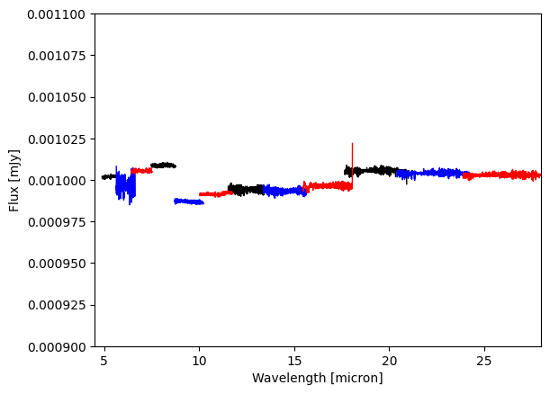

```python
for j in range(0,6):
    ip.main(band_chan[j],[1,2],1,1e-7)

    result=AssignWcsStep.call('mock'+band_chan[j]+'-00.fits',save_results=True)
    result=AssignWcsStep.call('mock'+band_chan[j]+'-01.fits',save_results=True)

    wtype=3
    band=indiv1[j]
    filenames='mock'+band_chan[j]+'-00_assignwcsstep.fits','mock'+band_chan[j]+'-01_assignwcsstep.fits'
    modshep.setcube(filenames, band, wtype)

    band=indiv2[j]
    filenames='mock'+band_chan[j]+'-00_assignwcsstep.fits','mock'+band_chan[j]+'-01_assignwcsstep.fits'
    modshep.setcube(filenames, band, wtype)

    image1,header1=fits.getdata('pystack/pycube'+indiv1[j]+'.fits',header=True)

    num_x1=header1["NAXIS2"]
    num_y1=header1["NAXIS1"]
    num_chan1=header1["NAXIS3"]
    start_wavelength1=header1["CRVAL3"]
    step_wavelength1=header1["CDELT3"]
    pix_size1=header1["CD2_2"]

    a1=[0.0]*num_chan1
    for i in range(0,num_chan1):
        for m in range(0,num_x1):
            for n in range(0,num_y1):
                a1[i]=image1[i,m,n]+a1[i]

    d1=[0.0]*num_chan1
    d1[0]=start_wavelength1
    for i in range(1,num_chan1):
        d1[i]=d1[i-1]+step_wavelength1

    for i in range(0,num_chan1):
        a1[i]=(a1[i]*(pix_size1*3600)*(pix_size1*3600)*(10**6))/(4.25*10**10)

    image2,header2=fits.getdata('pystack/pycube'+indiv2[j]+'.fits',header=True)

    num_x2=header2["NAXIS2"]
    num_y2=header2["NAXIS1"]
    num_chan2=header2["NAXIS3"]
    start_wavelength2=header2["CRVAL3"]
    step_wavelength2=header2["CDELT3"]
    pix_size2=header2["CD2_2"]

    a2=[0.0]*num_chan2
    for i in range(0,num_chan2):
        for m in range(0,num_x2):
            for n in range(0,num_y2):
                a2[i]=image2[i,m,n]+a2[i]

    d2=[0.0]*num_chan2
    d2[0]=start_wavelength2
    for i in range(1,num_chan2):
        d2[i]=d2[i-1]+step_wavelength2

    for i in range(0,num_chan2):
        a2[i]=(a2[i]*(pix_size2*3600)*(pix_size2*3600)*(10**6))/(4.25*10**10)


    plt.plot(d1,a1,'-', color=plot_color[j], lw=1)
    plt.plot(d2,a2,'-', color=plot_color[j], lw=1)
    plt.xlim(4.5,28)
    plt.ylim(0.0009,0.0011)
    plt.xlabel('Wavelength [micron]')
    plt.ylabel('Flux [mJy]')

plt.savefig('point_source_flux_conservation_modshep_all.pdf')
```

#### Use WCS corrected mock files to test cube build.

#### cube_testing.json file looks like the following:

#### {"asn_rule": "Asn_MIRIFU_Dither",

#### "targname": "MYTarget",

#### "asn_pool": "jw00024_001_01_pool",

#### "program": "0001",

#### "asn_type":"dither",

#### "asn_id": "a3001",

#### "target": "1",

#### "products": [ {"name": "det_image",

#### "members": [ {"exptype": "SCIENCE", "expname": "mock12A-00_assignwcsstep.fits"},

#### {"exptype": "SCIENCE", "expname": "mock12A-01_assignwcsstep.fits"} ] } ] }

#### result=CubeBuildStep.call('cube_testing.json',save_results=True) (this will run each channel/band individually)

#### result=CubeBuildStep.call('cube_testing.json',save_results=True, --output_type=multi) (this will make one cube as the final output)

```python
#The output should be 12 files: det_image_ch1-short_s3d.fits, det_image_ch1-medium_s3d.fits, etc.
result=CubeBuildStep.call('cube_testing.json',save_results=True)
```

[output not shown]

[output cut: 209 more lines]

```
2022-12-02 21:33:52,542 - stpipe.CubeBuildStep - INFO - Results used CRDS context: jwst_1019.pmap
2022-12-02 21:33:52,545 - stpipe.CubeBuildStep - INFO - Results used CRDS context: jwst_1019.pmap
2022-12-02 21:33:52,985 - stpipe.CubeBuildStep - INFO - Saved model in det_image_ch1-short_s3d.fits
2022-12-02 21:33:53,420 - stpipe.CubeBuildStep - INFO - Saved model in det_image_ch1-medium_s3d.fits
2022-12-02 21:33:53,877 - stpipe.CubeBuildStep - INFO - Saved model in det_image_ch1-long_s3d.fits
2022-12-02 21:33:54,300 - stpipe.CubeBuildStep - INFO - Saved model in det_image_ch2-short_s3d.fits
2022-12-02 21:33:55,655 - stpipe.CubeBuildStep - INFO - Saved model in det_image_ch2-medium_s3d.fits
2022-12-02 21:33:56,088 - stpipe.CubeBuildStep - INFO - Saved model in det_image_ch2-long_s3d.fits
2022-12-02 21:33:56,512 - stpipe.CubeBuildStep - INFO - Saved model in det_image_ch3-short_s3d.fits
2022-12-02 21:33:56,942 - stpipe.CubeBuildStep - INFO - Saved model in det_image_ch3-medium_s3d.fits
2022-12-02 21:33:57,378 - stpipe.CubeBuildStep - INFO - Saved model in det_image_ch3-long_s3d.fits
2022-12-02 21:33:57,798 - stpipe.CubeBuildStep - INFO - Saved model in det_image_ch4-short_s3d.fits
2022-12-02 21:33:58,221 - stpipe.CubeBuildStep - INFO - Saved model in det_image_ch4-medium_s3d.fits
2022-12-02 21:33:58,644 - stpipe.CubeBuildStep - INFO - Saved model in det_image_ch4-long_s3d.fits
2022-12-02 21:33:58,645 - stpipe.CubeBuildStep - INFO - Step CubeBuildStep done
```

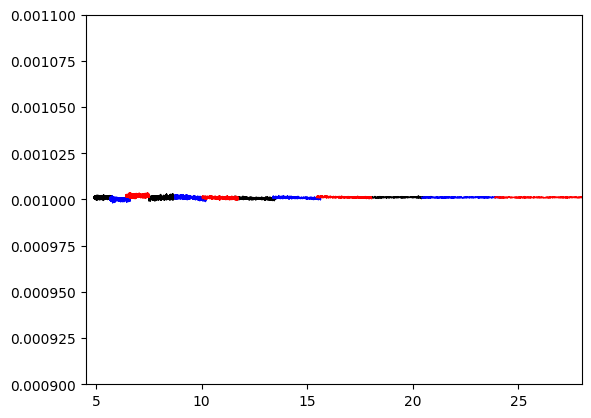

```python
#Define band and channels
band_chan=['ch1-short','ch2-short','ch3-short','ch4-short']

for j in range(0,4):
    image3,header3=fits.getdata('det_image_'+band_chan[j]+'_s3d.fits',header=True)

    num_x3=header3["NAXIS2"]
    num_y3=header3["NAXIS1"]
    num_chan3=header3["NAXIS3"]
    start_wavelength3=header3["CRVAL3"]
    step_wavelength3=header3["CDELT3"]
    pix_size3=header3["CDELT1"]

    a3=[0.0]*num_chan3
    for i in range(0,num_chan3):
        for m in range(0,num_x3):
            for n in range(0,num_y3):
                a3[i]=image3[i,m,n]+a3[i]

    d3=[0.0]*num_chan3
    d3[0]=start_wavelength3
    for i in range(1,num_chan3):
        d3[i]=d3[i-1]+step_wavelength3

    for i in range(0,num_chan3):
        a3[i]=(a3[i]*(pix_size3*3600)*(pix_size3*3600)*(10**6))/(4.25*10**10)

    plt.plot(d3,a3,'-', color='black', lw=1)
    plt.xlim(4.5,28)
    plt.ylim(0.0009,0.0011)

#Define band and channels
band_chan=['ch1-medium','ch2-medium','ch3-medium','ch4-medium']

for j in range(0,4):
    image3,header3=fits.getdata('det_image_'+band_chan[j]+'_s3d.fits',header=True)

    num_x3=header3["NAXIS2"]
    num_y3=header3["NAXIS1"]
    num_chan3=header3["NAXIS3"]
    start_wavelength3=header3["CRVAL3"]
    step_wavelength3=header3["CDELT3"]
    pix_size3=header3["CDELT1"]

    a3=[0.0]*num_chan3
    for i in range(0,num_chan3):
        for m in range(0,num_x3):
            for n in range(0,num_y3):
                a3[i]=image3[i,m,n]+a3[i]

    d3=[0.0]*num_chan3
    d3[0]=start_wavelength3
    for i in range(1,num_chan3):
        d3[i]=d3[i-1]+step_wavelength3

    for i in range(0,num_chan3):
        a3[i]=(a3[i]*(pix_size3*3600)*(pix_size3*3600)*(10**6))/(4.25*10**10)

    plt.plot(d3,a3,'-', color='blue', lw=1)
    plt.xlim(4.5,28)
    plt.ylim(0.0009,0.0011)

#Define band and channels
band_chan=['ch1-long','ch2-long','ch3-long','ch4-long']

for j in range(0,4):
    image3,header3=fits.getdata('det_image_'+band_chan[j]+'_s3d.fits',header=True)

    num_x3=header3["NAXIS2"]
    num_y3=header3["NAXIS1"]
    num_chan3=header3["NAXIS3"]
    start_wavelength3=header3["CRVAL3"]
    step_wavelength3=header3["CDELT3"]
    pix_size3=header3["CDELT1"]

    a3=[0.0]*num_chan3
    for i in range(0,num_chan3):
        for m in range(0,num_x3):
            for n in range(0,num_y3):
                a3[i]=image3[i,m,n]+a3[i]

    d3=[0.0]*num_chan3
    d3[0]=start_wavelength3
    for i in range(1,num_chan3):
        d3[i]=d3[i-1]+step_wavelength3

    for i in range(0,num_chan3):
        a3[i]=(a3[i]*(pix_size3*3600)*(pix_size3*3600)*(10**6))/(4.25*10**10)

    plt.plot(d3,a3,'-', color='red', lw=1)
    plt.xlim(4.5,28)
    plt.ylim(0.0009,0.0011)
```

#### Check the output of flat point source using Extract 1D

```python
#Do Band A things
band_chan=['ch1-short','ch2-short','ch3-short','ch4-short']
for i in range(0,4):
    temppath1='det_image_'+band_chan[i]+'_s3d.fits'
    print(temppath1)
    result=Extract1dStep.call(temppath1)
    result.save(band_chan[i]+"_output_file_from_extract1d.fits")

#Do Band B things
band_chan=['ch1-medium','ch2-medium','ch3-medium','ch4-medium']
for i in range(0,4):
    temppath1='det_image_'+band_chan[i]+'_s3d.fits'
    result=Extract1dStep.call(temppath1)
    result.save(band_chan[i]+"_output_file_from_extract1d.fits")

#Do Band C things
band_chan=['ch1-long','ch2-long','ch3-long','ch4-long']
for i in range(0,4):
    temppath1='det_image_'+band_chan[i]+'_s3d.fits'
    result=Extract1dStep.call(temppath1)
    result.save(band_chan[i]+"_output_file_from_extract1d.fits")
```

```
det_image_ch1-short_s3d.fits
```

```
2022-12-02 21:34:03,732 - stpipe.Extract1dStep - INFO - Extract1dStep instance created.
2022-12-02 21:34:04,518 - stpipe.Extract1dStep - INFO - Step Extract1dStep running with args ('det_image_ch1-short_s3d.fits',).
2022-12-02 21:34:04,521 - stpipe.Extract1dStep - INFO - Step Extract1dStep parameters are: {'pre_hooks': [], 'post_hooks': [], 'output_file': None, 'output_dir': None, 'output_ext': '.fits', 'output_use_model': False, 'output_use_index': True, 'save_results': False, 'skip': False, 'suffix': None, 's…
2022-12-02 21:34:04,791 - stpipe.Extract1dStep - INFO - Using EXTRACT1D reference file /grp/crds/cache/references/jwst/jwst_miri_extract1d_0003.asdf
2022-12-02 21:34:04,813 - stpipe.Extract1dStep - INFO - Using APCORR file /grp/crds/cache/references/jwst/jwst_miri_apcorr_0002.asdf
2022-12-02 21:34:06,265 - stpipe.Extract1dStep - INFO - Turning on source position correction for exp_type = MIR_MRS
2022-12-02 21:34:06,266 - stpipe.Extract1dStep - INFO - Source type = EXTENDED
2022-12-02 21:34:06,279 - stpipe.Extract1dStep - INFO - Input model does not break out variance information. Passing only generalized errors.
2022-12-02 21:34:15,290 - stpipe.Extract1dStep - INFO - Results used CRDS context: jwst_1019.pmap
2022-12-02 21:34:15,291 - stpipe.Extract1dStep - INFO - Step Extract1dStep done
```

```
det_image_ch2-short_s3d.fits
```

```
2022-12-02 21:34:15,579 - stpipe.Extract1dStep - INFO - Extract1dStep instance created.
2022-12-02 21:34:16,750 - stpipe.Extract1dStep - INFO - Step Extract1dStep running with args ('det_image_ch2-short_s3d.fits',).
2022-12-02 21:34:16,754 - stpipe.Extract1dStep - INFO - Step Extract1dStep parameters are: {'pre_hooks': [], 'post_hooks': [], 'output_file': None, 'output_dir': None, 'output_ext': '.fits', 'output_use_model': False, 'output_use_index': True, 'save_results': False, 'skip': False, 'suffix': None, 's…
2022-12-02 21:34:16,981 - stpipe.Extract1dStep - INFO - Using EXTRACT1D reference file /grp/crds/cache/references/jwst/jwst_miri_extract1d_0003.asdf
2022-12-02 21:34:17,000 - stpipe.Extract1dStep - INFO - Using APCORR file /grp/crds/cache/references/jwst/jwst_miri_apcorr_0002.asdf
2022-12-02 21:34:18,572 - stpipe.Extract1dStep - INFO - Turning on source position correction for exp_type = MIR_MRS
2022-12-02 21:34:18,572 - stpipe.Extract1dStep - INFO - Source type = EXTENDED
2022-12-02 21:34:18,586 - stpipe.Extract1dStep - INFO - Input model does not break out variance information. Passing only generalized errors.
2022-12-02 21:34:24,901 - stpipe.Extract1dStep - INFO - Results used CRDS context: jwst_1019.pmap
2022-12-02 21:34:24,902 - stpipe.Extract1dStep - INFO - Step Extract1dStep done
2022-12-02 21:34:25,180 - stpipe.Extract1dStep - INFO - Extract1dStep instance created.
```

```
det_image_ch3-short_s3d.fits
```

```
2022-12-02 21:34:25,384 - stpipe.Extract1dStep - INFO - Step Extract1dStep running with args ('det_image_ch3-short_s3d.fits',).
2022-12-02 21:34:25,386 - stpipe.Extract1dStep - INFO - Step Extract1dStep parameters are: {'pre_hooks': [], 'post_hooks': [], 'output_file': None, 'output_dir': None, 'output_ext': '.fits', 'output_use_model': False, 'output_use_index': True, 'save_results': False, 'skip': False, 'suffix': None, 's…
2022-12-02 21:34:25,599 - stpipe.Extract1dStep - INFO - Using EXTRACT1D reference file /grp/crds/cache/references/jwst/jwst_miri_extract1d_0003.asdf
2022-12-02 21:34:25,617 - stpipe.Extract1dStep - INFO - Using APCORR file /grp/crds/cache/references/jwst/jwst_miri_apcorr_0002.asdf
2022-12-02 21:34:27,187 - stpipe.Extract1dStep - INFO - Turning on source position correction for exp_type = MIR_MRS
2022-12-02 21:34:27,187 - stpipe.Extract1dStep - INFO - Source type = EXTENDED
2022-12-02 21:34:27,200 - stpipe.Extract1dStep - INFO - Input model does not break out variance information. Passing only generalized errors.
2022-12-02 21:34:34,107 - stpipe.Extract1dStep - INFO - Results used CRDS context: jwst_1019.pmap
2022-12-02 21:34:34,108 - stpipe.Extract1dStep - INFO - Step Extract1dStep done
2022-12-02 21:34:34,384 - stpipe.Extract1dStep - INFO - Extract1dStep instance created.
```

```
det_image_ch4-short_s3d.fits
```

[output not shown]

[output cut: 34 more lines]

[output not shown]

[output not shown]

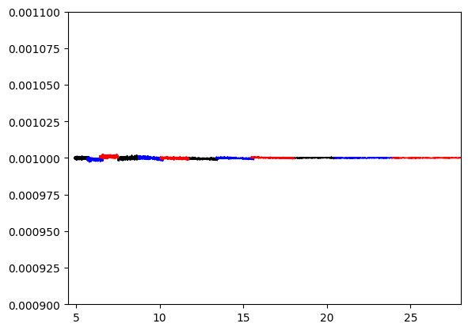

```python
#Plot Band A
band_chan=['ch1-short','ch2-short','ch3-short','ch4-short']
for i in range(0,4):
    read_output1=fits.open(band_chan[i]+"_output_file_from_extract1d.fits")
    data1=Table.read(read_output1, hdu=1)
    flux1=data1['FLUX']
    wavelength1=data1['WAVELENGTH']
    plt.plot(wavelength1,flux1,'-', color='black', lw=1)

#Plot Band B
band_chan=['ch1-medium','ch2-medium','ch3-medium','ch4-medium']
for i in range(0,4):
    read_output1=fits.open(band_chan[i]+"_output_file_from_extract1d.fits")
    data1=Table.read(read_output1, hdu=1)
    flux1=data1['FLUX']
    wavelength1=data1['WAVELENGTH']
    plt.plot(wavelength1,flux1,'-', color='blue', lw=1)

#Plot Band C
band_chan=['ch1-long','ch2-long','ch3-long','ch4-long']
for i in range(0,4):
    read_output1=fits.open(band_chan[i]+"_output_file_from_extract1d.fits")
    data1=Table.read(read_output1, hdu=1)
    flux1=data1['FLUX']
    wavelength1=data1['WAVELENGTH']
    plt.plot(wavelength1,flux1,'-', color='red', lw=1)
    plt.xlim(4.5,28)
    plt.ylim(0.0009,0.0011)
```

A successful test shows that the source is flat within 2%.